# Capstone_2 slides

#### Olist Store a Brazilian E-Commerce Company

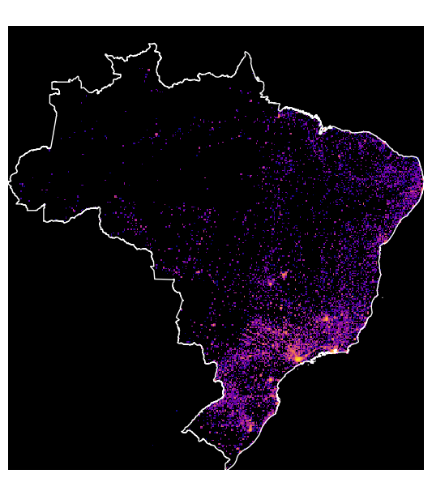

### Executive Summary Take Aways

- **Most sales come out of the Southeast Region.**
- **The Southeast region has more sales than any other Region, but the lowest average sales.**
- **The North and Northeast regions have larger sales because of possible inconvenience to the customer of products that they want, but no sellers available near them?**
- **All the different regions sell pretty much the same Top 10 categories of product.**

### My Recommendation

- **Begin acquiring more sellers in the Northeast region as there is nearly as much customer demand as the South Region and has twice the population of the South. This could be a great area for potential growth and help support the demand from customers in the North Region.**
- **Begin acquiring more sellers in the Central-West Region as their customers base is close to that of the Northeast region and can also provide better service to the Northern Region.**
- **Doing this will give opportunity for growth and cut down on delivery times to customers in the North. This is a Key Point Indicator that should be tracked.**

**From November 2016 to September 2018, Olist Store provided data on the 5 regions of Brazil, generating over 19 million Reals. The Southeast Region had the highest sales volume during this period.**

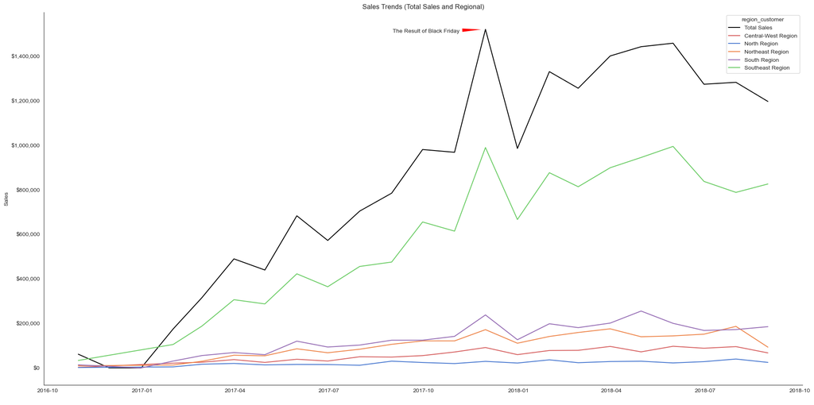

**The Southeast Region had the highest sales of 12.55M Reals, outperforming all the regions capturing ~ 65% of all the sales. Followed by the South Region with ~ 15% (2.86M Reals). The North Region with only ~ 2% (0.46M Reals). These figures clearly indicate that a majority of the sales were made in the states located in the Southeast and South Regions.**

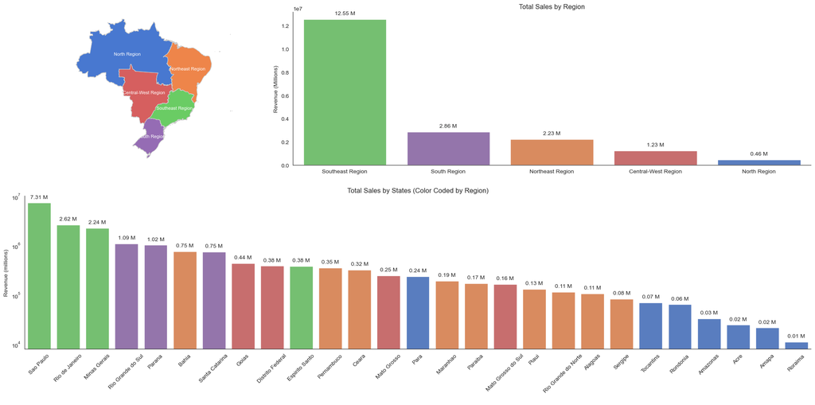

**Interesting to note that the average ticket sale for each region is nearly opposite to their total sales. Where The North Region’s average sale is 225.41 Reals is ~39% more than the Southeast Region of 161.66 Reals, followed closely by the Northeast Region with 214.20 Reals.**

[figure not shown]

**The two maps illustrate the relationship between the number of sellers and customers in each region and state. The majority of sellers and customers are located in the South and Southeast Regions, with ~109K Sellers (~98% of all sellers) and ~94K Customers (~91% of all customers). In contrast, the North Region with 25 sellers and over 2000 Customers. Due to the vast distances from the east coast of Brazil, packages must travel long distances to reach their destination.**

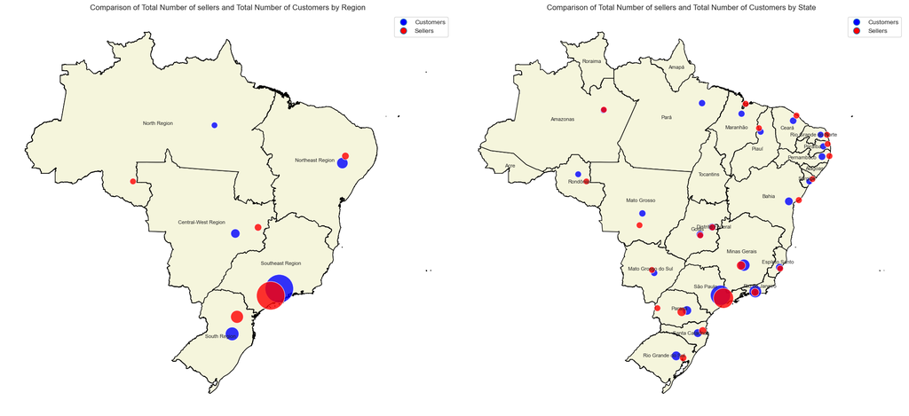

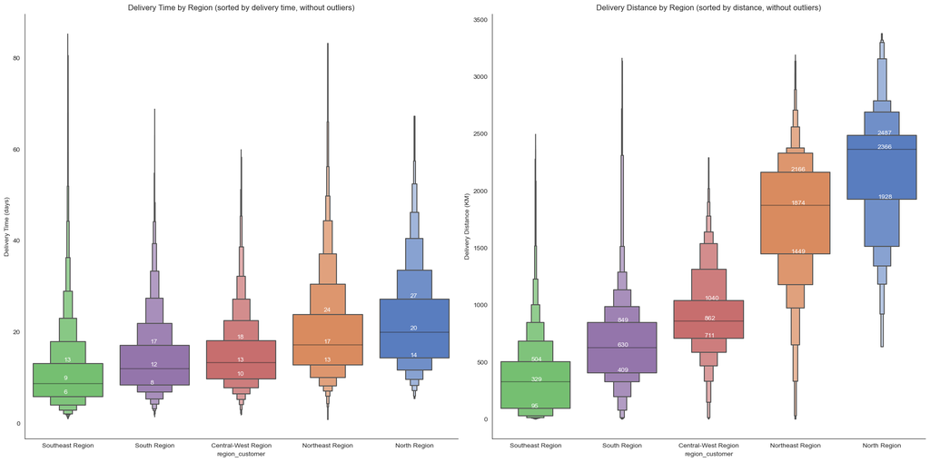

**The delivery time for customers increases gradually as we move from Sao Paulo on the southeastern coast to Roraima in the North. However, the delivery distance to customers changes significantly when they are located outside the Southern Regions.**

[figure not shown]

**The top 10 categories of products that customers are interested in are similar across all regions. The main difference is the time it takes for customers to receive their orders.**

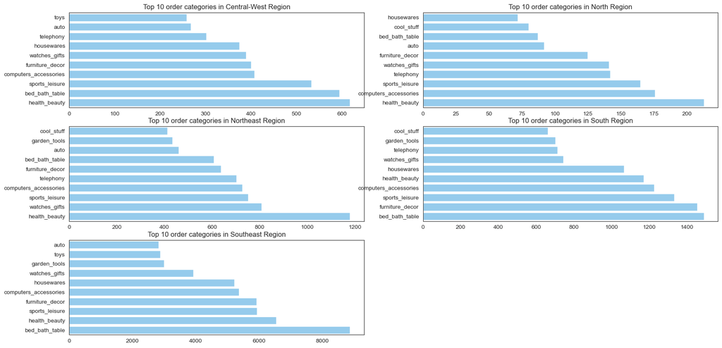

```
20:08:35 - cmdstanpy - INFO - Chain [1] start processing
20:08:43 - cmdstanpy - INFO - Chain [1] done processing
```

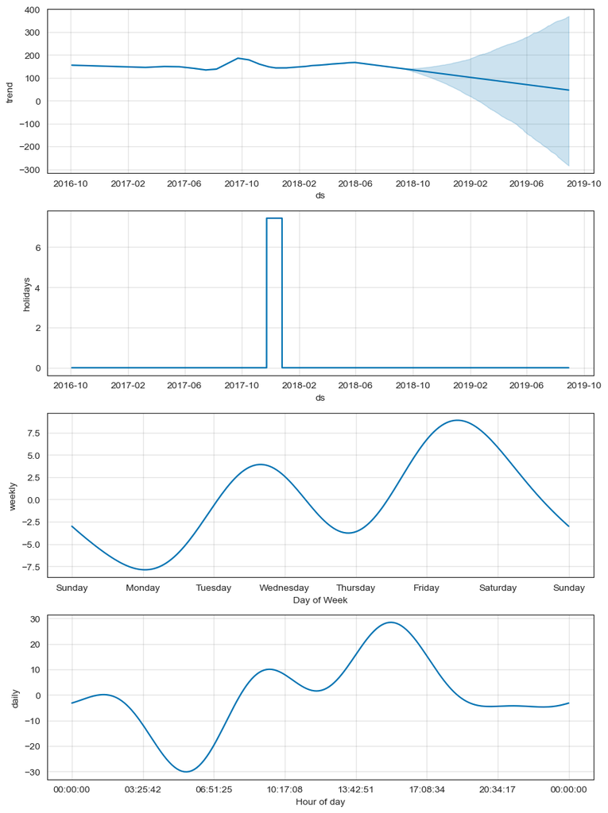

[output not shown]